# Updated descriptive statistics

David Henderson

05, March, 2019

# Introduction

**updated 2019-02-27** following recleaning of SCS file

After initial look at models we have agreed to change some variable groupings (e.g. 5-year age bands instead of 10). I have also changed the way in which I counted prescriptions.

These changes have been made to the original wrangling files. I have overwritten the `df_main` object in `15_join_all.Rmd` and then usewd this to create `df_comorb` (with Charlson and Elix scores) in `21_comorb_scores.Rmd`.

This has obviously had an effect on numbers (although small I think) and I’ll need to re-do descriptives.

Getting a feel for outcomes with the inital models has also led me to the decision to drop all data from 2016/17. It is really only USC data that is completed well for that year and it is outside by defined study period.

## Packages

First of all I load in required packages and some of my own helper functions.

```r
library(finalfit)
library(tidyverse) #For ...well everything
library(magrittr)  #Pipe operators
library(lubridate) #Dates (not loaded with tidyverse)
library(extrafont) #For plot font options
library(DT)        #Print pretty tables in html with buttons
library(ggthemes)  #scale_fill_ptol()
library(ggalt)     #geom_lollipop()
library(glue)
library(rlang)

#Set the base plotting options
theme_set(theme_minimal(base_size = 16))

#My own helper functions
`%nin%` <- Negate(`%in%`) #negate the %in% function
source("Research/functions/round_df.R") #Round-up all numeric values in a df
source("Research/functions/my_datatable.R") #quick datatable

#From @kjhealy's book "Data visualisation"
#Two functions to tidy up variable names in model outputs
source("Research/functions/prefix_funcs.R")

#Set breaks and labels for plots here (saves re-writing them for
#facet plots etc.)
year_breaks <- c(ymd(20120331), ymd(20130331),
                 ymd(20140331), ymd(20150331),
                 ymd(20160331))

year_labels <- c(`2012-03-31` = "2011/12",
                 `2013-03-31` = "2012/13",
                 `2014-03-31` = "2013/14",
                 `2015-03-31` = "2014/15",
                 `2016-03-31` = "2015/16")

#Finally an expression that can be used programatically with case_when()
#note: needs library(rlang)
year_char <- exprs(
           year == ymd(20110331) ~ "2010/11",
           year == ymd(20120331) ~ "2011/12",
           year == ymd(20130331) ~ "2012/13",
           year == ymd(20140331) ~ "2013/14",
           year == ymd(20150331) ~ "2014/15",
           year == ymd(20160331) ~ "2015/16",
           year == ymd(20170331) ~ "2016/17"
)
```

## Load data

Now I load in the previously tidied main data frame. (Note this has comorbidity scores added for those that had an admission during the period 2011/12-2016/17)

```r
load("Research/created_objects/clean_data/df_comorb.rds")
```

# Tidy data

A few things need changed to tidy up the dataframe as it is now.

## Drop unneeded years of data

```r
df_comorb %<>%
  filter(year != ymd(20170331)) %>% #Only USC data available for this year
  filter(year != ymd(20110331)) #No deaths data available for this year
```

## Tidy flags

I made a lot of the flags integers when creating them. I will replace these as factor variables and label appropriately

```r
df_comorb %<>%
  mutate(care_home = factor(care_home,
                            levels = c("0", "1"),
                            labels = c("Not Care Home", "Care Home")),
         demos_flag = if_else(is.na(demos_flag) | demos_flag == 0, 0L,
                              as.integer(demos_flag)),
         demos_flag = factor(demos_flag,
                             levels = c(0, 1),
                             labels = c("Not present in demos file",
                                        "Present in demos file")),
         pis_flag = if_else(is.na(pis_flag), 0L,
                                  as.integer(pis_flag)),
         pis_flag = factor(pis_flag,
                           levels = c(0, 1),
                           labels = c("No repeat meds", "Has repeat meds")),
         scs_flag = if_else(is.na(scs_flag) | scs_flag == 0, 0L,
                                  as.integer(scs_flag)),
         scs_flag = factor(scs_flag,
                           levels = c(0, 1),
                           labels = c("No Social Care", "Social Care")),
         hc_flag = if_else(is.na(total_hrs) | total_hrs == 0, 0, 1),
         hc_flag = factor(hc_flag,
                          levels = c(0, 1),
                          labels = c("No Home Care", "Home Care")),
         usc_flag = if_else(is.na(usc_flag) | usc_flag == 0, 0L,
                                  as.integer(usc_flag)),
         usc_flag = factor(usc_flag,
                           levels = c(0, 1),
                           labels = c("No USC", "USC")),
         total_ch = if_else(is.na(total_ch) | total_ch == 0, 0L,
                                  as.integer(total_ch)),
         ltc_count = if_else(is.na(ltc_count) | ltc_count == 0, 0L,
                                   as.integer(ltc_count)),
         n_usc_ep = if_else(is.na(n_usc_ep) | n_usc_ep == 0 , 0L,
                            as.integer(n_usc_ep)),
         n_admission = if_else(is.na(n_admission) | n_admission == 0, 0L,
                               as.integer(n_admission)),
         adm_flag = if_else(n_admission > 0, TRUE, FALSE), #error was here
         n_ed = if_else(is.na(n_ed) | n_ed == 0, 0L,
                        as.integer(n_ed)),
         ed_flag = if_else(n_ed > 0, TRUE, FALSE)
  ) -> thesis
save(thesis, file = "Research/created_objects/clean_data/thesis.rds")
rm(df_comorb)
```

# Describe

## Count

Using the `finalfit` package. I need to coerce the year variable to a character first though…

```r
thesis$year <- as.character(thesis$year)
thesis$year <- factor(thesis$year)

dependent = "year"
explanatory = c("is.na(dod)", "sex", "age", "age_grp", "pis_flag", "scs_flag",
                "care_home", "hc_flag", "usc_flag", "adm_flag", "ed_flag")

thesis %>%
  summary_factorlist(dependent, explanatory,
                     column = TRUE,
                     add_dependent_label = TRUE,
                     dependent_label_prefix = "") -> tab_main
```

…Now add a count of total indiviudals in each year and print out

```r
thesis %>%
  group_by(year) %>%
  summarise(n = n()) %>%
  ungroup %>%
  mutate(n = as.character(n)) %>%
  spread(year, n) %>%
  mutate(year = "n") %>%
  bind_rows(., tab_main) %>%
  select(c(6:7), everything()) -> tab_main
tab_main
```

| year |  | 2012-03-31 | 2013-03-31 | 2014-03-31 | 2015-03-31 | 2016-03-31 |
| --- | --- | --- | --- | --- | --- | --- |
| n | NA | 870923 | 895113 | 908300 | 920647 | 924323 |
| is.na(dod) | FALSE | 35876 (4.1) | 41702 (4.7) | 39346 (4.3) | 42365 (4.6) | 37992 (4.1) |
|  | TRUE | 835047 (95.9) | 853411 (95.3) | 868954 (95.7) | 878282 (95.4) | 886331 (95.9) |
| sex | Male | 382598 (43.9) | 395927 (44.2) | 404478 (44.5) | 412128 (44.8) | 415968 (45.0) |
|  | Female | 488325 (56.1) | 499186 (55.8) | 503822 (55.5) | 508519 (55.2) | 508355 (55.0) |
| age | Mean (SD) | 74.8 (7.4) | 74.7 (7.4) | 74.7 (7.4) | 74.7 (7.4) | 74.7 (7.4) |
| age_grp | 65-69 | 256764 (29.5) | 269044 (30.1) | 274946 (30.3) | 278708 (30.3) | 282563 (30.6) |
|  | 70-74 | 206133 (23.7) | 208831 (23.3) | 211466 (23.3) | 214391 (23.3) | 215895 (23.4) |
|  | 75-79 | 170455 (19.6) | 173475 (19.4) | 175402 (19.3) | 176749 (19.2) | 175279 (19.0) |
|  | 80-84 | 124680 (14.3) | 127608 (14.3) | 128500 (14.1) | 130149 (14.1) | 130135 (14.1) |

[output cut: 17 more lines]

```r
#my_datatable(tab_main)
```

I also need a value for the total number of indiviudals across all years of data

```r
thesis %>%
  summarise(n = n_distinct(index))
```

| n |
| --- |
| 1100675 |

## Total population

Plot the total pop over time..

```r
#coerce year back to date variable
thesis$year <- ymd(thesis$year)

thesis %>%
  group_by(year) %>%
  summarise(n = n_distinct(index)) -> pop_tab
my_datatable(pop_tab)
```

|  | year | n |
| --- | --- | --- |
| 1 | 2012-03-31 | 870923 |
| 2 | 2013-03-31 | 895113 |
| 3 | 2014-03-31 | 908300 |
| 4 | 2015-03-31 | 920647 |
| 5 | 2016-03-31 | 924323 |

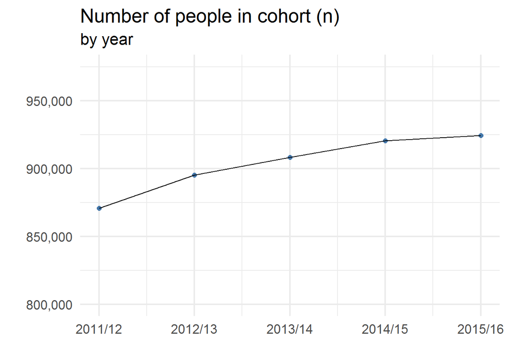

```r
pop_tab %>%
  ggplot(aes(year, n)) +
  geom_point(colour = "#4477AA", size = 2) +
  geom_path() +
  scale_x_date(breaks = year_breaks,
               labels = year_labels) +
  scale_y_continuous(limits = c(800000, 975000),
                     breaks = scales::pretty_breaks(),
                     label = scales::comma) +
  labs(title = "Number of people in cohort (n)",
       subtitle = "by year",
       x = "",
       y = "") -> pop_count
pop_count
```

## Age and sex

```r
thesis %>%
  filter(year == ymd(20160331)) %>%
  group_by(sex) %>%
  count(age_grp) %>%
  ungroup %>%
  mutate(frq = round(n/sum(n),3)) -> age_tab
my_datatable(age_tab)
```

|  | sex | age_grp | n | frq |
| --- | --- | --- | --- | --- |
| 1 | Male | 65-69 | 139171 | 0.151 |
| 2 | Male | 70-74 | 102723 | 0.111 |
| 3 | Male | 75-79 | 78765 | 0.085 |
| 4 | Male | 80-84 | 54642 | 0.059 |
| 5 | Male | 85-89 | 28392 | 0.031 |
| 6 | Male | 90-94 | 10182 | 0.011 |
| 7 | Male | 95 plus | 2093 | 0.002 |
| 8 | Female | 65-69 | 143392 | 0.155 |
| 9 | Female | 70-74 | 113172 | 0.122 |
| 10 | Female | 75-79 | 96514 | 0.104 |

[output cut: 4 more lines]

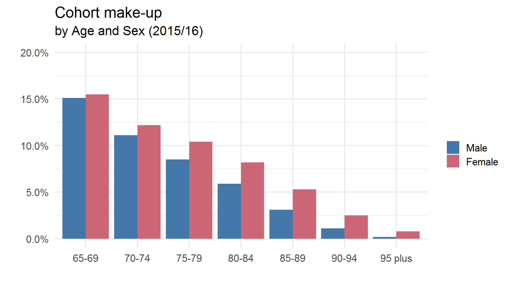

```r
age_tab %>%
  ggplot(aes(age_grp, frq, fill = sex)) +
  geom_col(position = "dodge") +
  scale_fill_ptol() +
  scale_y_continuous(labels = scales::percent_format(),
                     limits = c(0, 0.2)) +
  labs(title = "Cohort make-up",
       subtitle = "by Age and Sex (2015/16)",
       x = "",
       y = "",
       fill = "") -> age_sex_plot
age_sex_plot
```

## Deaths

```r
thesis %>%
  group_by(year, is.na(dod), sex) %>%
  count(age_grp) %>%
  group_by(year, `is.na(dod)`) %>%
  mutate(frq = round(n/sum(n), 3)) %>%
  filter(`is.na(dod)` == FALSE) %>%
  filter(year == ymd(20160331)) -> deaths_tab
my_datatable(deaths_tab)
```

|  | year | is.na(dod) | sex | age_grp | n | frq |
| --- | --- | --- | --- | --- | --- | --- |
| 1 | 2016-03-31 | False | Male | 65-69 | 2325 | 0.061 |
| 2 | 2016-03-31 | False | Male | 70-74 | 2813 | 0.074 |
| 3 | 2016-03-31 | False | Male | 75-79 | 3526 | 0.093 |
| 4 | 2016-03-31 | False | Male | 80-84 | 3730 | 0.098 |
| 5 | 2016-03-31 | False | Male | 85-89 | 3122 | 0.082 |
| 6 | 2016-03-31 | False | Male | 90-94 | 1666 | 0.044 |
| 7 | 2016-03-31 | False | Male | 95 plus | 425 | 0.011 |
| 8 | 2016-03-31 | False | Female | 65-69 | 1625 | 0.043 |
| 9 | 2016-03-31 | False | Female | 70-74 | 2170 | 0.057 |
| 10 | 2016-03-31 | False | Female | 75-79 | 3088 | 0.081 |

[output cut: 4 more lines]

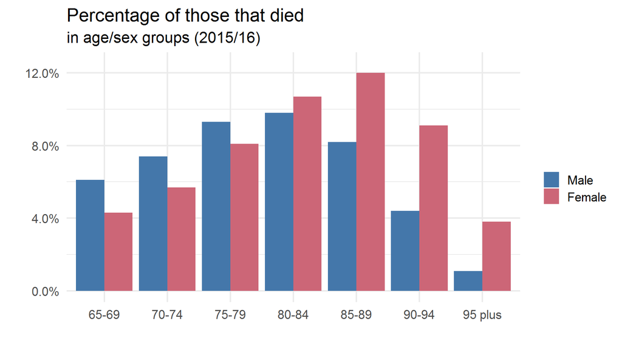

```r
deaths_tab %>%
  ggplot(aes(age_grp, frq, fill = sex)) +
  geom_col(position = "dodge") +
  scale_fill_ptol() +
  scale_y_continuous(labels = scales::percent_format(),
                     limits = c(0, 0.125)) +
  labs(title = "Percentage of those that died",
       subtitle = "in age/sex groups (2015/16)",
       x = "",
       y = "",
       fill = "") -> deaths_plot
deaths_plot
```

## LA

Use 2015/16 again

```r
thesis %>%
  filter(year == ymd(20160331)) %>%
  count(council, sort = TRUE) %>%
  mutate(frq = round(n/sum(n), 3)) -> la_tab
my_datatable(la_tab)
```

|  | council | n | frq |
| --- | --- | --- | --- |
| 1 | Glasgow City | 81004 | 0.088 |
| 2 | City of Edinburgh | 71868 | 0.078 |
| 3 | Fife | 70103 | 0.076 |
| 4 | South Lanarkshire | 55604 | 0.06 |
| 5 | North Lanarkshire | 53080 | 0.057 |
| 6 | Highland | 43969 | 0.048 |
| 7 | Aberdeenshire | 43007 | 0.047 |
| 8 | Dumfries and Galloway | 35373 | 0.038 |
| 9 | Aberdeen City | 33368 | 0.036 |
| 10 | Renfrewshire | 30892 | 0.033 |

[output cut: 21 more lines]

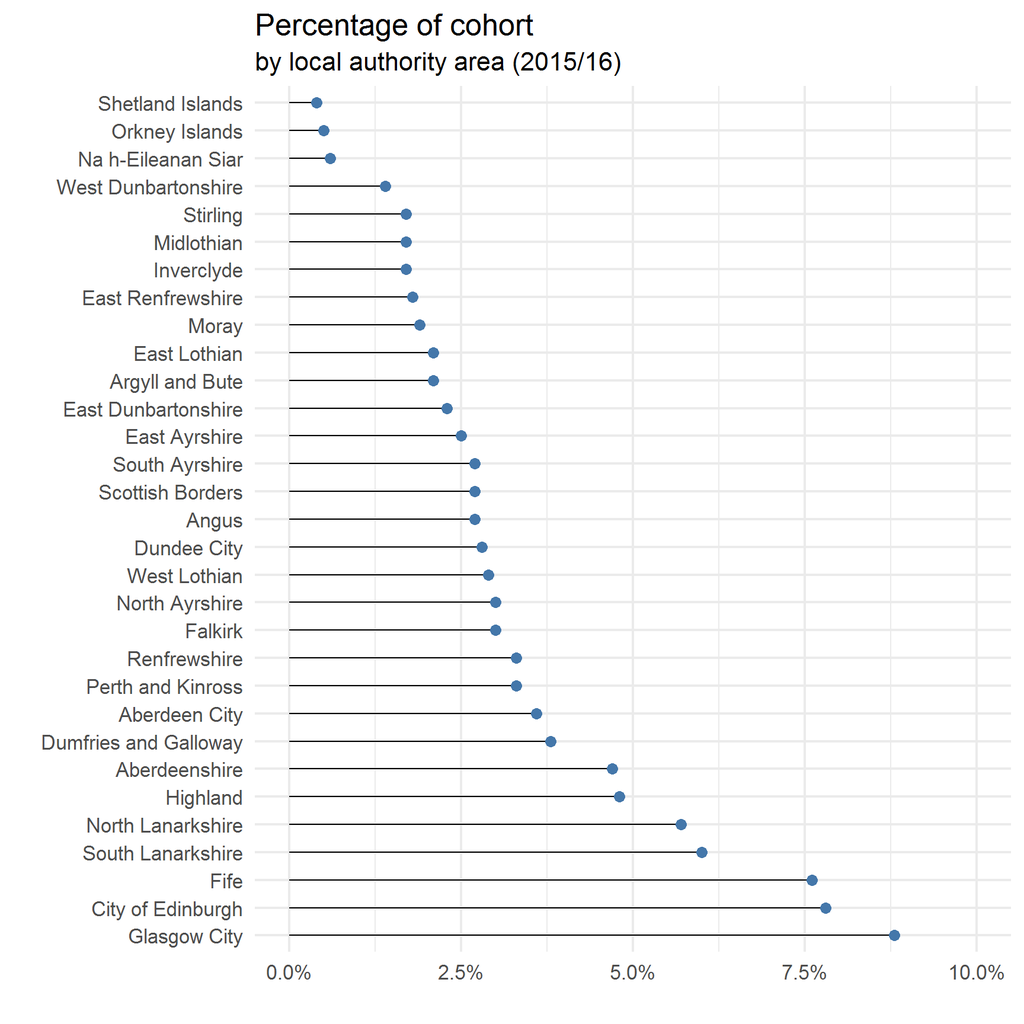

```r
la_tab %>%
  ggplot(aes(reorder(council, -frq), frq)) +
  geom_lollipop(point.colour = "#4477AA",
                point.size = 3) +
  scale_y_continuous(labels = scales::percent_format(),
                     limits = c(0, 0.1)) +
  coord_flip() +
  labs(title = "Percentage of cohort",
       subtitle = "by local authority area (2015/16)",
       x = "",
       y = "") -> la_count
la_count
```